# Assignment 2

Arnav Murulidhar

9/14/2020

## Setup

The libraries needed for the assignment:

```r
library(tidyverse)
library(ggplot2)
```

Then I’ll load the dataset from Assignment 1 and attach it to the search path

```r
tract_data <- read_csv("commutersLosAngelesCA2018.csv")
attach(tract_data)
```

### List of variables (from Assignment 1):

1. Property value (continuous) : VALP
2. Units in structure (categorical) : BLD
3. Total person’s income (continuous) : PINCP
4. Means of transportation to work (categorical) : JWTR
5. Travel time to work (continuous) : JWMNP

## Distribution of Continuous Variables

### Descriptive statistics

First I calculate summary statistics.

```r
prop_summary <-  summary(VALP)
prop_sd <- sd(VALP, na.rm = TRUE)
prop_mean_int <- t.test(VALP)
income_summary <- summary(PINCP)
income_sd <- sd(PINCP, na.rm = TRUE)
income_mean_int <- t.test(PINCP)
commute_summary <- summary(JWMNP)
commute_sd <- sd(JWMNP, na.rm = TRUE)
commute_mean_int <- t.test(JWMNP)
```

And display them in a formatted table:

```r
summary_table <- tibble(
  Statistic = c("Sample mean",
                "Median",
                "Standard deviation",
                "Interquartile range",
                "Population mean (95% confidence)"),
  `Property value ( $ )` = c(prettyNum(prop_summary["Mean"], digits=3),
                           prop_summary["Median"],
                           prettyNum(prop_sd, digits = 3),
                           paste(prop_summary["1st Qu."],"to",
                                 prop_summary["3rd Qu."]),
                           paste(prettyNum(prop_mean_int$conf.int[1],
                                           digits=3), "to",
                                 prettyNum(prop_mean_int$conf.int[2],
                                               digits=3))),
  `Income ( $ )` = c(paste(prettyNum(income_summary["Mean"], digits=3)),
                           paste(prettyNum(income_summary["Median"],digits=3)),
                           paste(prettyNum(income_sd, digits=3)),
                           paste(prettyNum(income_summary["1st Qu."], digits=3),
                                 " to",
                                 prettyNum(income_summary["3rd Qu."], digits=3)),
                           paste(prettyNum(income_mean_int$conf.int[1],
                                           digits=3), " to",
                                 prettyNum(income_mean_int$conf.int[2],
                                           digits=3))),
  `Commute time (min)` = c(paste(prettyNum(commute_summary["Mean"], digits=3)),
                          paste(prettyNum(commute_summary["Median"], digits=3)),
                          paste(prettyNum(commute_sd, digits=3)),
                          paste(prettyNum(commute_summary["1st Qu."], digits=3),
                                " to",
                          prettyNum(commute_summary["3rd Qu."], digits=3)),
                          paste(prettyNum(commute_mean_int$conf.int[1],
                                           digits=3), " to",
                          prettyNum(commute_mean_int$conf.int[2],
                                           digits=3))))
knitr::kable(summary_table,
             caption = "Characteristics of select data from a census tract in Los Angeles")
```

Characteristics of select data from a census tract in Los Angeles

| Statistic | Property value ( $ ) | Income ( $ ) | Commute time (min) |
| --- | --- | --- | --- |
| Sample mean | 745666 | 75797 | 33.3 |
| Median | 550000 | 49000 | 30 |
| Standard deviation | 773464 | 99903 | 24.5 |
| Interquartile range | 435000 to 8e+05 | 25000 to 90000 | 15 to 45 |
| Population mean (95% confidence) | 735931 to 755402 | 74540 to 77055 | 33 to 33.6 |

### Histograms

Now, I’ll create histogram for each of these three distributions.

#### Property Value

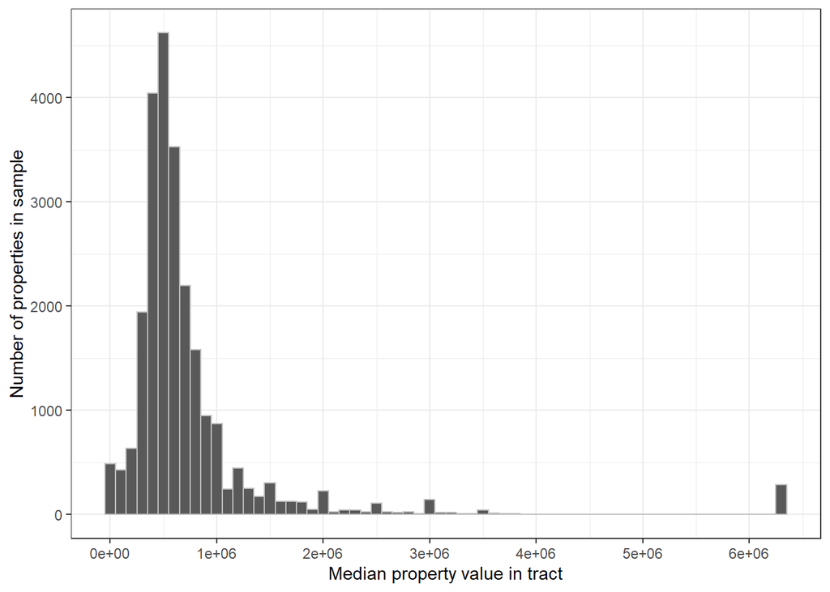

```r
ggplot(tract_data, aes(x = VALP)) +
  geom_histogram(color = "gray", binwidth = 100000) +
  theme_bw() +
  scale_x_continuous(name = "Median property value in tract",
                    breaks = seq(0, 6000000, by = 1000000)) +
  scale_y_continuous(name = "Number of properties in sample")
```

The distribution of property value looks positively skewed, thus the median value is less than the corresponding mean value. The outlier values increases the mean quite a bit.

#### Income

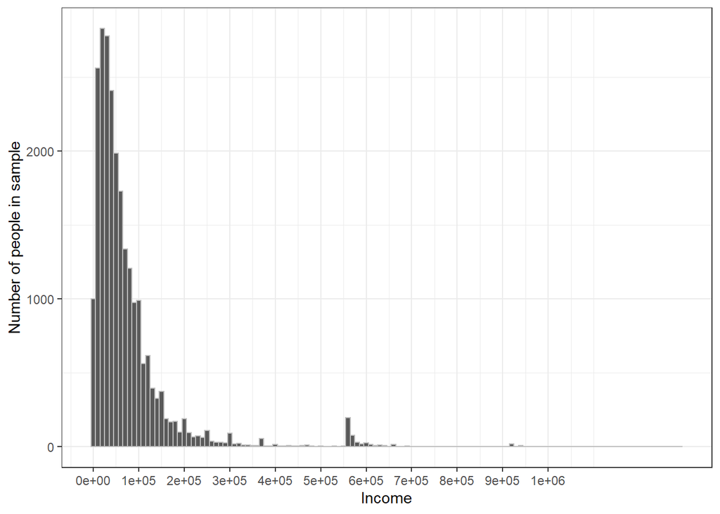

```r
ggplot(tract_data, aes(x = PINCP)) +
  geom_histogram(color = "gray", binwidth = 10000) +
  theme_bw() +
  scale_x_continuous(name = "Income",
                     breaks = seq(0, 1000000, by = 100000)) +
  scale_y_continuous(name = "Number of people in sample")
```

The distribution of income is also skewed to the right, with a long tail.

#### Commute time

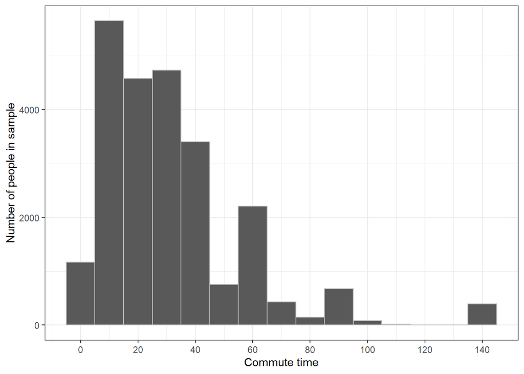

```r
ggplot(tract_data, aes(x = JWMNP)) +
  geom_histogram(color = "gray", binwidth = 10) +
  theme_bw() +
  scale_x_continuous(name =
    "Commute time",
                     breaks = seq(0, 140, by = 20)) +
  scale_y_continuous(name = "Number of people in sample")
```

The distribution of commute time is slightly skewed to the right, with outliers at the 140min mark. However, you can see that the bulk of commute times range between 15-45 minutes.

## Distribution of Categorical Variables

### Unit types

First I’ll do a t-test for each housing type.

```r
one_det <- t.test (BLD == "02")
three_apt <- t.test (BLD == "05")
one_att <- t.test (BLD == "03")
ten_apt <- t.test (BLD == "07")
mob_home <- t.test (BLD == "01")
twen_apt <- t.test (BLD == "08")
fifty_apt <- t.test (BLD == "09")
five_apt <- t.test (BLD == "06")
two_apt <- t.test (BLD == "04")
boat_rv <- t.test (BLD == "10")
```

Then I’ll create a formatted table with proportions and confidence intervals

```r
struct_shares <- tibble(Struct_types = c("One-family house detached",
                                  "3-4 Apartments",
                                  "One-family house attached",
                                  "10-19 Apartments",
                                  "Mobile home or trailer",
                                  "20-49 Apartments",
                                  "50 or more Apartments",
                                  "5-9 Apartments",
                                  "2 Apartments",
                                  "Boat, RV, van, etc."),
                 Sample_proportion = c(paste(prettyNum(one_det$estimate*100,
                                                         digits = 3), "%"),
                                         paste(prettyNum(three_apt$estimate*100,
                                                         digits = 3), "%"),
                                         paste(prettyNum(one_att$estimate*100,
                                                         digits = 3), "%"),
                                         paste(prettyNum(ten_apt$estimate*100,
                                                         digits = 3), "%"),
                                         paste(prettyNum(mob_home$estimate*100,
                                                         digits = 3), "%"),
                                         paste(prettyNum(twen_apt$estimate*100,
                                                         digits = 3), "%"),
                                         paste(prettyNum(fifty_apt$estimate*100,
                                                         digits = 3), "%"),
                                         paste(prettyNum(five_apt$estimate*100,
                                                         digits = 3), "%"),
                                         paste(prettyNum(two_apt$estimate*100,
                                                         digits = 3), "%"),
                                         paste(prettyNum(boat_rv$estimate*100,
                                                         digits = 3), "%")),
                 `95-percent confidence interval` = c(
                   paste(prettyNum(one_det$conf.int[1]*100, digits=3),
                         "% to ",
                         prettyNum(one_det$conf.int[2]*100, digits=3),
                         "%", sep=""),
                   paste(prettyNum(three_apt$conf.int[1]*100, digits=3),
                         "% to ",
                         prettyNum(three_apt$conf.int[2]*100, digits=3),
                         "%", sep=""),
                   paste(prettyNum(one_att$conf.int[1]*100, digits=3),
                         "% to ",
                         prettyNum(one_att$conf.int[2]*100, digits=3),
                         "%", sep=""),
                   paste(prettyNum(ten_apt$conf.int[1]*100, digits=3),
                         "% to ",
                         prettyNum(ten_apt$conf.int[2]*100, digits=3),
                         "%", sep=""),
                   paste(prettyNum(mob_home$conf.int[1]*100, digits=3),
                         "% to ",
                         prettyNum(mob_home$conf.int[2]*100, digits=3),
                         "%", sep=""),
                   paste(prettyNum(twen_apt$conf.int[1]*100, digits=3),
                         "% to ",
                         prettyNum(twen_apt$conf.int[2]*100, digits=3),
                         "%", sep=""),
                   paste(prettyNum(fifty_apt$conf.int[1]*100, digits=3),
                         "% to ",
                         prettyNum(fifty_apt$conf.int[2]*100, digits=3),
                         "%", sep=""),
                   paste(prettyNum(five_apt$conf.int[1]*100, digits=3),
                         "% to ",
                         prettyNum(five_apt$conf.int[2]*100, digits=3),
                         "%", sep=""),
                   paste(prettyNum(two_apt$conf.int[1]*100, digits=3),
                         "% to ",
                         prettyNum(two_apt$conf.int[2]*100, digits=3),
                         "%", sep=""),
                   paste(prettyNum(boat_rv$conf.int[1]*100, digits=3),
                         "% to ",
                         prettyNum(boat_rv$conf.int[2]*100, digits=3),
                         "%", sep="")))


knitr::kable(struct_shares, caption = "Characteristics of select data from a census tract in Los Angeles")
```

Characteristics of select data from a census tract in Los Angeles

| Struct_types | Sample_proportion | 95-percent confidence interval |
| --- | --- | --- |
| One-family house detached | 84.8 % | 84.3% to 85.2% |
| 3-4 Apartments | 1.05 % | 0.919% to 1.18% |
| One-family house attached | 6.86 % | 6.54% to 7.18% |
| 10-19 Apartments | 0.981 % | 0.857% to 1.11% |
| Mobile home or trailer | 1.92 % | 1.74% to 2.09% |
| 20-49 Apartments | 1.3 % | 1.16% to 1.45% |
| 50 or more Apartments | 1.48 % | 1.33% to 1.63% |
| 5-9 Apartments | 0.854 % | 0.738% to 0.969% |
| 2 Apartments | 0.763 % | 0.653% to 0.872% |
| Boat, RV, van, etc. | 0.0289 % | 0.00748% to 0.0503% |

```r
car <- t.test (BLD == "01")
bus <- t.test (BLD == "02")
streetcar <- t.test (BLD == "03")
subway <- t.test (BLD == "04")
railroad <- t.test (BLD == "05")
ferry <- t.test (BLD == "06")
taxi <- t.test (BLD == "07")
motorcycle <- t.test (BLD == "08")
bicycle <- t.test (BLD == "09")
walked <- t.test (BLD == "10")
other <- t.test (BLD == "12")
```

```r
commute_shares <- tibble(Commute_types = c("Car, truck or van",
                                  "Bus or trolleybus",
                                  "Streetcar",
                                  "Subway",
                                  "Railroad",
                                  "Ferryboat",
                                  "Taxicab",
                                  "Motorcycle",
                                  "Bicycle",
                                  "Walked",
                                  "Other"),
                 Sample_proportion = c(paste(prettyNum(car$estimate*100,
                                                         digits = 3), "%"),
                                         paste(prettyNum(bus$estimate*100,
                                                         digits = 3), "%"),
                                         paste(prettyNum(streetcar$estimate*100,
                                                         digits = 3), "%"),
                                         paste(prettyNum(subway$estimate*100,
                                                         digits = 3), "%"),
                                         paste(prettyNum(railroad$estimate*100,
                                                         digits = 3), "%"),
                                         paste(prettyNum(ferry$estimate*100,
                                                         digits = 3), "%"),
                                         paste(prettyNum(taxi$estimate*100,
                                                         digits = 3), "%"),
                                         paste(prettyNum(motorcycle$estimate*100,
                                                         digits = 3), "%"),
                                         paste(prettyNum(bicycle$estimate*100,
                                                         digits = 3), "%"),
                                         paste(prettyNum(walked$estimate*100,
                                                         digits = 3), "%"),
                                         paste(prettyNum(other$estimate*100,
                                                         digits = 3), "%")),
                 `95-percent confidence interval` = c(
                   paste(prettyNum(car$conf.int[1]*100, digits=3),
                         "% to ",
                         prettyNum(car$conf.int[2]*100, digits=3),
                         "%", sep=""),
                   paste(prettyNum(bus$conf.int[1]*100, digits=3),
                         "% to ",
                         prettyNum(bus$conf.int[2]*100, digits=3),
                         "%", sep=""),
                   paste(prettyNum(streetcar$conf.int[1]*100, digits=3),
                         "% to ",
                         prettyNum(streetcar$conf.int[2]*100, digits=3),
                         "%", sep=""),
                   paste(prettyNum(subway$conf.int[1]*100, digits=3),
                         "% to ",
                         prettyNum(subway$conf.int[2]*100, digits=3),
                         "%", sep=""),
                   paste(prettyNum(railroad$conf.int[1]*100, digits=3),
                         "% to ",
                         prettyNum(railroad$conf.int[2]*100, digits=3),
                         "%", sep=""),
                   paste(prettyNum(ferry$conf.int[1]*100, digits=3),
                         "% to ",
                         prettyNum(ferry$conf.int[2]*100, digits=3),
                         "%", sep=""),
                   paste(prettyNum(taxi$conf.int[1]*100, digits=3),
                         "% to ",
                         prettyNum(taxi$conf.int[2]*100, digits=3),
                         "%", sep=""),
                   paste(prettyNum(motorcycle$conf.int[1]*100, digits=3),
                         "% to ",
                         prettyNum(motorcycle$conf.int[2]*100, digits=3),
                         "%", sep=""),
                   paste(prettyNum(bicycle$conf.int[1]*100, digits=3),
                         "% to ",
                         prettyNum(bicycle$conf.int[2]*100, digits=3),
                         "%", sep=""),
                         paste(prettyNum(walked$conf.int[1]*100, digits=3),
                         "% to ",
                         prettyNum(walked$conf.int[2]*100, digits=3),
                         "%", sep=""),
                   paste(prettyNum(other$conf.int[1]*100, digits=3),
                         "% to ",
                         prettyNum(other$conf.int[2]*100, digits=3),
                         "%", sep="")))


knitr::kable(struct_shares, caption = "Characteristics of select data from a census tract in Los Angeles")
```

Characteristics of select data from a census tract in Los Angeles

| Struct_types | Sample_proportion | 95-percent confidence interval |
| --- | --- | --- |
| One-family house detached | 84.8 % | 84.3% to 85.2% |
| 3-4 Apartments | 1.05 % | 0.919% to 1.18% |
| One-family house attached | 6.86 % | 6.54% to 7.18% |
| 10-19 Apartments | 0.981 % | 0.857% to 1.11% |
| Mobile home or trailer | 1.92 % | 1.74% to 2.09% |
| 20-49 Apartments | 1.3 % | 1.16% to 1.45% |
| 50 or more Apartments | 1.48 % | 1.33% to 1.63% |
| 5-9 Apartments | 0.854 % | 0.738% to 0.969% |
| 2 Apartments | 0.763 % | 0.653% to 0.872% |
| Boat, RV, van, etc. | 0.0289 % | 0.00748% to 0.0503% |